# Initial Code for Classification & Prediction of Forest Cover in Roosevelt National Park, CO, USA

Haley Aldred

09 November 2021

# Introduction

This report contains my initial code for examining my data set, which will be used in classifying and predicting forest cover types in Roosevelt National Forest in Colorado, USA. My data comes from the UCI Machine Learning Repository (https://archive.ics.uci.edu/ml/machine-learning-databases/covtype/).

# Preparation Work

## Loading Libraries

[output not shown]

## Data Exploration

Loading the data

```r
covtype.data <- read.csv("~/School/CIND820/data/covtype.data.gz", header=FALSE, stringsAsFactors=TRUE)
View(covtype.data)
```

Changing the name of the data

```r
data<-covtype.data
```

Looking at the first few rows of data

```r
head(data)
```

```
    V1  V2 V3  V4  V5   V6  V7  V8  V9  V10 V11 V12 V13 V14 V15 V16 V17 V18 V19
1 2596  51  3 258   0  510 221 232 148 6279   1   0   0   0   0   0   0   0   0
2 2590  56  2 212  -6  390 220 235 151 6225   1   0   0   0   0   0   0   0   0
3 2804 139  9 268  65 3180 234 238 135 6121   1   0   0   0   0   0   0   0   0
4 2785 155 18 242 118 3090 238 238 122 6211   1   0   0   0   0   0   0   0   0
5 2595  45  2 153  -1  391 220 234 150 6172   1   0   0   0   0   0   0   0   0
6 2579 132  6 300 -15   67 230 237 140 6031   1   0   0   0   0   0   0   0   0
  V20 V21 V22 V23 V24 V25 V26 V27 V28 V29 V30 V31 V32 V33 V34 V35 V36 V37 V38
1   0   0   0   0   0   0   0   0   0   0   0   0   0   0   0   0   0   0   0
2   0   0   0   0   0   0   0   0   0   0   0   0   0   0   0   0   0   0   0
3   0   0   0   0   0   0   1   0   0   0   0   0   0   0   0   0   0   0   0
4   0   0   0   0   0   0   0   0   0   0   0   0   0   0   0   0   0   0   0
5   0   0   0   0   0   0   0   0   0   0   0   0   0   0   0   0   0   0   0
6   0   0   0   0   0   0   0   0   0   0   0   0   0   0   0   0   0   0   0
  V39 V40 V41 V42 V43 V44 V45 V46 V47 V48 V49 V50 V51 V52 V53 V54 V55
1   0   0   0   0   1   0   0   0   0   0   0   0   0   0   0   0   5
2   0   0   0   0   1   0   0   0   0   0   0   0   0   0   0   0   5
3   0   0   0   0   0   0   0   0   0   0   0   0   0   0   0   0   2
4   0   0   0   0   0   1   0   0   0   0   0   0   0   0   0   0   2
5   0   0   0   0   1   0   0   0   0   0   0   0   0   0   0   0   5
6   0   0   0   0   1   0   0   0   0   0   0   0   0   0   0   0   2
```

Adding column names based off the *covtype.info* document

```r
colnames(data)<-c("elev", "aspect", "slope", "hHydro", "vHydro", "hRoad", "hs09", "hs12", "hs15", "hFire", "wild1", "wild2", "wild3", "wild4", "s1", "s2", "s3", "s4", "s5", "s6", "s7", "s8", "s9", "s10", "s11", "s12", "s13", "s14", "s15", "s16", "s17", "s18", "s19", "s20", "s21", "s22", "s23", "s24", "s25", "s26", "s27", "s28", "s29", "s30", "s31", "s32", "s33", "s34", "s35", "s36", "s37", "s38", "s39", "s40", "treeType")
```

Verifying the column names have been updated

```r
head(data)
```

```
  elev aspect slope hHydro vHydro hRoad hs09 hs12 hs15 hFire wild1 wild2 wild3
1 2596     51     3    258      0   510  221  232  148  6279     1     0     0
2 2590     56     2    212     -6   390  220  235  151  6225     1     0     0
3 2804    139     9    268     65  3180  234  238  135  6121     1     0     0
4 2785    155    18    242    118  3090  238  238  122  6211     1     0     0
5 2595     45     2    153     -1   391  220  234  150  6172     1     0     0
6 2579    132     6    300    -15    67  230  237  140  6031     1     0     0
  wild4 s1 s2 s3 s4 s5 s6 s7 s8 s9 s10 s11 s12 s13 s14 s15 s16 s17 s18 s19 s20
1     0  0  0  0  0  0  0  0  0  0   0   0   0   0   0   0   0   0   0   0   0
2     0  0  0  0  0  0  0  0  0  0   0   0   0   0   0   0   0   0   0   0   0
3     0  0  0  0  0  0  0  0  0  0   0   0   1   0   0   0   0   0   0   0   0
4     0  0  0  0  0  0  0  0  0  0   0   0   0   0   0   0   0   0   0   0   0
5     0  0  0  0  0  0  0  0  0  0   0   0   0   0   0   0   0   0   0   0   0
6     0  0  0  0  0  0  0  0  0  0   0   0   0   0   0   0   0   0   0   0   0
  s21 s22 s23 s24 s25 s26 s27 s28 s29 s30 s31 s32 s33 s34 s35 s36 s37 s38 s39
1   0   0   0   0   0   0   0   0   1   0   0   0   0   0   0   0   0   0   0
2   0   0   0   0   0   0   0   0   1   0   0   0   0   0   0   0   0   0   0
3   0   0   0   0   0   0   0   0   0   0   0   0   0   0   0   0   0   0   0
4   0   0   0   0   0   0   0   0   0   1   0   0   0   0   0   0   0   0   0
5   0   0   0   0   0   0   0   0   1   0   0   0   0   0   0   0   0   0   0
6   0   0   0   0   0   0   0   0   1   0   0   0   0   0   0   0   0   0   0
  s40 treeType
1   0        5
2   0        5
3   0        2
4   0        2
5   0        5
6   0        2
```

Looking at the last few rows of data

```r
tail(data)
```

```
       elev aspect slope hHydro vHydro hRoad hs09 hs12 hs15 hFire wild1 wild2
581007 2401    157    21     90     15   120  238  238  119   830     0     0
581008 2396    153    20     85     17   108  240  237  118   837     0     0
581009 2391    152    19     67     12    95  240  237  119   845     0     0
581010 2386    159    17     60      7    90  236  241  130   854     0     0
581011 2384    170    15     60      5    90  230  245  143   864     0     0
581012 2383    165    13     60      4    67  231  244  141   875     0     0
       wild3 wild4 s1 s2 s3 s4 s5 s6 s7 s8 s9 s10 s11 s12 s13 s14 s15 s16 s17
581007     1     0  0  1  0  0  0  0  0  0  0   0   0   0   0   0   0   0   0
581008     1     0  0  1  0  0  0  0  0  0  0   0   0   0   0   0   0   0   0
581009     1     0  0  1  0  0  0  0  0  0  0   0   0   0   0   0   0   0   0
581010     1     0  0  1  0  0  0  0  0  0  0   0   0   0   0   0   0   0   0
581011     1     0  0  1  0  0  0  0  0  0  0   0   0   0   0   0   0   0   0
581012     1     0  0  1  0  0  0  0  0  0  0   0   0   0   0   0   0   0   0
       s18 s19 s20 s21 s22 s23 s24 s25 s26 s27 s28 s29 s30 s31 s32 s33 s34 s35
581007   0   0   0   0   0   0   0   0   0   0   0   0   0   0   0   0   0   0
581008   0   0   0   0   0   0   0   0   0   0   0   0   0   0   0   0   0   0
581009   0   0   0   0   0   0   0   0   0   0   0   0   0   0   0   0   0   0
581010   0   0   0   0   0   0   0   0   0   0   0   0   0   0   0   0   0   0
581011   0   0   0   0   0   0   0   0   0   0   0   0   0   0   0   0   0   0
581012   0   0   0   0   0   0   0   0   0   0   0   0   0   0   0   0   0   0
       s36 s37 s38 s39 s40 treeType
581007   0   0   0   0   0        3
581008   0   0   0   0   0        3
581009   0   0   0   0   0        3
581010   0   0   0   0   0        3
581011   0   0   0   0   0        3
581012   0   0   0   0   0        3
```

Verifying that there are no missing values

```r
colSums(is.na(data))
```

```
    elev   aspect    slope   hHydro   vHydro    hRoad     hs09     hs12
       0        0        0        0        0        0        0        0
    hs15    hFire    wild1    wild2    wild3    wild4       s1       s2
       0        0        0        0        0        0        0        0
      s3       s4       s5       s6       s7       s8       s9      s10
       0        0        0        0        0        0        0        0
     s11      s12      s13      s14      s15      s16      s17      s18
       0        0        0        0        0        0        0        0
     s19      s20      s21      s22      s23      s24      s25      s26
       0        0        0        0        0        0        0        0
     s27      s28      s29      s30      s31      s32      s33      s34
       0        0        0        0        0        0        0        0
     s35      s36      s37      s38      s39      s40 treeType
       0        0        0        0        0        0        0
```

Looking at the structure of the data

```r
str(data)
```

```
'data.frame':   581012 obs. of  55 variables:
 $ elev    : int  2596 2590 2804 2785 2595 2579 2606 2605 2617 2612 ...
 $ aspect  : int  51 56 139 155 45 132 45 49 45 59 ...
 $ slope   : int  3 2 9 18 2 6 7 4 9 10 ...
 $ hHydro  : int  258 212 268 242 153 300 270 234 240 247 ...
 $ vHydro  : int  0 -6 65 118 -1 -15 5 7 56 11 ...
 $ hRoad   : int  510 390 3180 3090 391 67 633 573 666 636 ...
 $ hs09    : int  221 220 234 238 220 230 222 222 223 228 ...
 $ hs12    : int  232 235 238 238 234 237 225 230 221 219 ...
 $ hs15    : int  148 151 135 122 150 140 138 144 133 124 ...
 $ hFire   : int  6279 6225 6121 6211 6172 6031 6256 6228 6244 6230 ...
 $ wild1   : int  1 1 1 1 1 1 1 1 1 1 ...
 $ wild2   : int  0 0 0 0 0 0 0 0 0 0 ...
 $ wild3   : int  0 0 0 0 0 0 0 0 0 0 ...
 $ wild4   : int  0 0 0 0 0 0 0 0 0 0 ...
```

[output cut: 41 more lines]

Looking at the basic data statistics

```r
summary(data)
```

```
      elev          aspect          slope          hHydro
 Min.   :1859   Min.   :  0.0   Min.   : 0.0   Min.   :   0.0
 1st Qu.:2809   1st Qu.: 58.0   1st Qu.: 9.0   1st Qu.: 108.0
 Median :2996   Median :127.0   Median :13.0   Median : 218.0
 Mean   :2959   Mean   :155.7   Mean   :14.1   Mean   : 269.4
 3rd Qu.:3163   3rd Qu.:260.0   3rd Qu.:18.0   3rd Qu.: 384.0
 Max.   :3858   Max.   :360.0   Max.   :66.0   Max.   :1397.0
     vHydro            hRoad           hs09            hs12
 Min.   :-173.00   Min.   :   0   Min.   :  0.0   Min.   :  0.0
 1st Qu.:   7.00   1st Qu.:1106   1st Qu.:198.0   1st Qu.:213.0
 Median :  30.00   Median :1997   Median :218.0   Median :226.0
 Mean   :  46.42   Mean   :2350   Mean   :212.1   Mean   :223.3
 3rd Qu.:  69.00   3rd Qu.:3328   3rd Qu.:231.0   3rd Qu.:237.0
 Max.   : 601.00   Max.   :7117   Max.   :254.0   Max.   :254.0
      hs15           hFire          wild1            wild2
 Min.   :  0.0   Min.   :   0   Min.   :0.0000   Min.   :0.00000
 1st Qu.:119.0   1st Qu.:1024   1st Qu.:0.0000   1st Qu.:0.00000
 Median :143.0   Median :1710   Median :0.0000   Median :0.00000
 Mean   :142.5   Mean   :1980   Mean   :0.4489   Mean   :0.05143
 3rd Qu.:168.0   3rd Qu.:2550   3rd Qu.:1.0000   3rd Qu.:0.00000
 Max.   :254.0   Max.   :7173   Max.   :1.0000   Max.   :1.00000
     wild3            wild4               s1                 s2
 Min.   :0.0000   Min.   :0.00000   Min.   :0.000000   Min.   :0.00000
 1st Qu.:0.0000   1st Qu.:0.00000   1st Qu.:0.000000   1st Qu.:0.00000
 Median :0.0000   Median :0.00000   Median :0.000000   Median :0.00000
 Mean   :0.4361   Mean   :0.06363   Mean   :0.005217   Mean   :0.01295
 3rd Qu.:1.0000   3rd Qu.:0.00000   3rd Qu.:0.000000   3rd Qu.:0.00000
 Max.   :1.0000   Max.   :1.00000   Max.   :1.000000   Max.   :1.00000
       s3                 s4                s5                 s6
 Min.   :0.000000   Min.   :0.00000   Min.   :0.000000   Min.   :0.00000
 1st Qu.:0.000000   1st Qu.:0.00000   1st Qu.:0.000000   1st Qu.:0.00000
 Median :0.000000   Median :0.00000   Median :0.000000   Median :0.00000
 Mean   :0.008301   Mean   :0.02134   Mean   :0.002749   Mean   :0.01132
 3rd Qu.:0.000000   3rd Qu.:0.00000   3rd Qu.:0.000000   3rd Qu.:0.00000
 Max.   :1.000000   Max.   :1.00000   Max.   :1.000000   Max.   :1.00000
       s7                  s8                  s9                s10
 Min.   :0.0000000   Min.   :0.0000000   Min.   :0.000000   Min.   :0.00000
 1st Qu.:0.0000000   1st Qu.:0.0000000   1st Qu.:0.000000   1st Qu.:0.00000
 Median :0.0000000   Median :0.0000000   Median :0.000000   Median :0.00000
 Mean   :0.0001807   Mean   :0.0003081   Mean   :0.001974   Mean   :0.05617
```

[output cut: 43 more lines]

```
 Max.   :1.00000   Max.   :1.00000   Max.   :1.00000   Max.   :1.000000
      s35                s36                 s37                 s38
 Min.   :0.000000   Min.   :0.0000000   Min.   :0.0000000   Min.   :0.0000
 1st Qu.:0.000000   1st Qu.:0.0000000   1st Qu.:0.0000000   1st Qu.:0.0000
 Median :0.000000   Median :0.0000000   Median :0.0000000   Median :0.0000
 Mean   :0.003255   Mean   :0.0002048   Mean   :0.0005129   Mean   :0.0268
 3rd Qu.:0.000000   3rd Qu.:0.0000000   3rd Qu.:0.0000000   3rd Qu.:0.0000
 Max.   :1.000000   Max.   :1.0000000   Max.   :1.0000000   Max.   :1.0000
      s39               s40             treeType
 Min.   :0.00000   Min.   :0.00000   Min.   :1.000
 1st Qu.:0.00000   1st Qu.:0.00000   1st Qu.:1.000
 Median :0.00000   Median :0.00000   Median :2.000
 Mean   :0.02376   Mean   :0.01506   Mean   :2.051
 3rd Qu.:0.00000   3rd Qu.:0.00000   3rd Qu.:2.000
 Max.   :1.00000   Max.   :1.00000   Max.   :7.000
```

The mean elevation of the area is 2959 m. The mean distance to water is 269.4 m. The mean distance to roads is 2350 m.The median tree type is number 2, also known as the lodgepole pine. The summary function is not really useful for wilderness area or soil type attributes as they are multiple binary columns.

To determine soil count numbers, the sum function will be used.

```r
sum(data$s1 !=0)
```

```
[1] 3031
```

```r
sum(data$s32 !=0)
```

```
[1] 52519
```

The psych package will be used to take a closer look at the data.

```r
describe(data)
```

```
         vars      n    mean      sd  min  max range   se
elev        1 581012 2959.37  279.98 1859 3858  1999 0.37
aspect      2 581012  155.66  111.91    0  360   360 0.15
slope       3 581012   14.10    7.49    0   66    66 0.01
hHydro      4 581012  269.43  212.55    0 1397  1397 0.28
vHydro      5 581012   46.42   58.30 -173  601   774 0.08
hRoad       6 581012 2350.15 1559.25    0 7117  7117 2.05
hs09        7 581012  212.15   26.77    0  254   254 0.04
hs12        8 581012  223.32   19.77    0  254   254 0.03
hs15        9 581012  142.53   38.27    0  254   254 0.05
hFire      10 581012 1980.29 1324.20    0 7173  7173 1.74
wild1      11 581012    0.45    0.50    0    1     1 0.00
wild2      12 581012    0.05    0.22    0    1     1 0.00
wild3      13 581012    0.44    0.50    0    1     1 0.00
wild4      14 581012    0.06    0.24    0    1     1 0.00
s1         15 581012    0.01    0.07    0    1     1 0.00
s2         16 581012    0.01    0.11    0    1     1 0.00
s3         17 581012    0.01    0.09    0    1     1 0.00
s4         18 581012    0.02    0.14    0    1     1 0.00
s5         19 581012    0.00    0.05    0    1     1 0.00
s6         20 581012    0.01    0.11    0    1     1 0.00
s7         21 581012    0.00    0.01    0    1     1 0.00
s8         22 581012    0.00    0.02    0    1     1 0.00
s9         23 581012    0.00    0.04    0    1     1 0.00
s10        24 581012    0.06    0.23    0    1     1 0.00
s11        25 581012    0.02    0.14    0    1     1 0.00
s12        26 581012    0.05    0.22    0    1     1 0.00
s13        27 581012    0.03    0.17    0    1     1 0.00
s14        28 581012    0.00    0.03    0    1     1 0.00
s15        29 581012    0.00    0.00    0    1     1 0.00
s16        30 581012    0.00    0.07    0    1     1 0.00
s17        31 581012    0.01    0.08    0    1     1 0.00
s18        32 581012    0.00    0.06    0    1     1 0.00
s19        33 581012    0.01    0.08    0    1     1 0.00
s20        34 581012    0.02    0.13    0    1     1 0.00
s21        35 581012    0.00    0.04    0    1     1 0.00
s22        36 581012    0.06    0.23    0    1     1 0.00
s23        37 581012    0.10    0.30    0    1     1 0.00
s24        38 581012    0.04    0.19    0    1     1 0.00
s25        39 581012    0.00    0.03    0    1     1 0.00
s26        40 581012    0.00    0.07    0    1     1 0.00
s27        41 581012    0.00    0.04    0    1     1 0.00
s28        42 581012    0.00    0.04    0    1     1 0.00
s29        43 581012    0.20    0.40    0    1     1 0.00
s30        44 581012    0.05    0.22    0    1     1 0.00
s31        45 581012    0.04    0.21    0    1     1 0.00
s32        46 581012    0.09    0.29    0    1     1 0.00
s33        47 581012    0.08    0.27    0    1     1 0.00
s34        48 581012    0.00    0.05    0    1     1 0.00
s35        49 581012    0.00    0.06    0    1     1 0.00
s36        50 581012    0.00    0.01    0    1     1 0.00
s37        51 581012    0.00    0.02    0    1     1 0.00
s38        52 581012    0.03    0.16    0    1     1 0.00
s39        53 581012    0.02    0.15    0    1     1 0.00
s40        54 581012    0.02    0.12    0    1     1 0.00
treeType   55 581012    2.05    1.40    1    7     6 0.00
```

This gives a mean and standard deviation for all attributes, but it is only useful for first 10 attributes. Lets create a table for each wilderness type to view the number of instances for each attribute.

```r
table(data$wild1)
```

```
     0      1
320216 260796
```

```r
table(data$wild2)
```

```
     0      1
551128  29884
```

```r
table(data$wild3)
```

```
     0      1
327648 253364
```

```r
table(data$wild4)
```

```
     0      1
544044  36968
```

This indicates that there are 260796 instances for wilderness area 1 (Rawah), 29884 instances for wilderness area 2 (Neota), 253364 instances for wilderness area 3 (Comanche Peak), and 36968 instances for wilderness area 4 (Cache la Poudre). The Rawah wilderness area has the most instances in the collected data, next is Comanche Peak.

Lets create a table of the different tree types.

```r
table(data$treeType)
```

```
     1      2      3      4      5      6      7
211840 283301  35754   2747   9493  17367  20510
```

This means there are 211840 instances of tree type 1 (spruce/fir), 283301 instances of tree type 2 (lodgepole pine), 35754 instances of tree type 3 (ponderosa pine), 2747 instances of tree type 4 (cottonwood/willow), 9493 instances of tree type 5 (aspen), 17367 instances of tree type 6 (douglas-fir), and 20510 instances of tree type 7 (krummholz). Tree type 2, or lodgepole pine, is the most frequent tree type found in the national forest. Cottonwood/willow trees are the most rare tree type in the forest.

Lets look at the distribution of elevation for the data set.

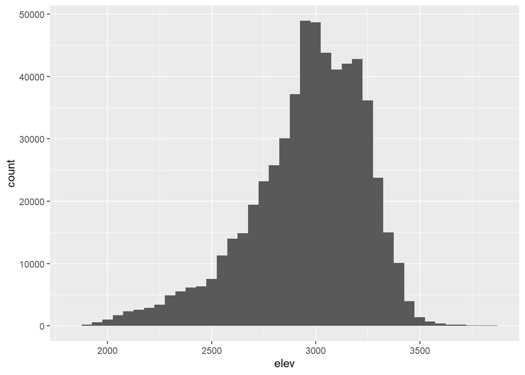

```r
ggplot(data, aes(x=elev))+geom_histogram(binwidth=50)
```